# Survey-weighted Difference-in-Differences: combining `balance` and `diff-diff` on a BRFSS-style smoking-ban policy

This tutorial shows an end-to-end **survey-weighted causal-inference** workflow in pure Python, using two complementary open-source tools, bridged by a thin adapter:

1. [`balance`](https://import-balance.org/) to make a complex survey sample **representative** of a known population frame (ACS demographics) via poststratification / raking — and to carry a design-consistent weight column with valid effective-sample-size and standard-error accounting.
2. [`diff_diff`](https://github.com/igerber/diff-diff) to estimate a modern staggered **Callaway–Sant'Anna** Difference-in-Differences with built-in survey-design variance and HonestDiD sensitivity.
3. The thin adapter `balance.interop.diff_diff` (added in balance 0.21) that hands a `balance.Sample` straight to a diff-diff estimator — building the `SurveyDesign`, aggregating respondents to a geo-period panel, and stripping balance's book-keeping columns for you.

**The running question.** *Did state indoor-smoking bans (adopted 2020 and 2022) reduce adult asthma prevalence relative to states without bans, 2018–2024?* The microdata mirrors the public-use BRFSS file ([CDC BRFSS](https://www.cdc.gov/brfss/annual_data/annual_2024.html)), but we generate it synthetically so the notebook is self-contained and deterministic. The one cell that builds the synthetic frame is exactly the cell you would replace with a real `pyreadstat.read_xport(...)` call.

**Two lessons, one pipeline.** BRFSS response rates have declined for decades, and the decline is concentrated among younger adults — so the realized sample ages over time even though the design weights are nominally correct. We will see that this differential non-response:

- **biases a descriptive estimand** (the national prevalence *trend*) badly — and `balance` fixes it; and
- **largely cancels in the DiD** — so the causal ATT is reassuringly robust to composition, while `balance` still supplies the correct design-based standard errors. That robustness is a feature, and the survey weights are what let you *verify* it.

**Pre-requisites.** `pandas`, basic causal-inference vocabulary (treatment, control, parallel trends), and ideally the [balance quickstart](https://import-balance.org/docs/tutorials/quickstart/). No R or Stata assumed.

## Setup

You need a build of `balance` that ships `balance.interop.diff_diff` (v0.21+) and `diff-diff` (>= 3.3). The simplest install is:

```
pip install "balance[did]"
```

which pulls `diff-diff>=3.3.0,<4` as an optional extra. If you already have balance, `pip install diff-diff` is sufficient.

```python
import logging
import warnings

import matplotlib.pyplot as plt
import numpy as np
import pandas as pd

# balance - survey reweighting against a population frame
import balance
from balance import Sample

# balance.interop.diff_diff - the thin adapter (added in balance 0.21)
from balance.interop import diff_diff as bd
from balance.interop.diff_diff import as_balance_diagnostic, fit_did

# diff-diff - survey-aware DiD estimators + sensitivity
import diff_diff as dd
from diff_diff import compute_honest_did

warnings.filterwarnings("ignore", category=FutureWarning, module="balance")
# Keep the tutorial output focused on results, not balance's INFO/WARNING logs.
logging.getLogger("balance").setLevel(logging.ERROR)

print(f"balance:   {balance.__version__}")
print(f"diff-diff: {dd.__version__}")
```

[output not shown]

[output not shown]

```
balance:   0.23.0
diff-diff: 3.12.0
```

## The dataset

We build a **respondent-level** synthetic frame that mirrors BRFSS 2018–2024: 50 states × 7 years × ~150 adult respondents per state-year (~54,000 rows). Each respondent has:

- demographics `age_band`, `educ_cat`, `sex`, `race` (the variables we poststratify on);
- a binary outcome `asthnow` ∈ {0, 1} (currently has asthma), drawn from a logistic model with a baseline prevalence near 9%;
- a complex survey design: `stratum` (region type), `psu` (county cluster), `fpc`, and a `design_weight` standing in for BRFSS `_LLCPWT`;
- `g`, the year a state's smoking ban took effect (`0` = never-treated).

Two things are baked into the data generator. First, the smoking ban lowers asthma prevalence by about 3 percentage points in treated states after adoption (parallel trends hold in the *population*). Second — the realistic wrinkle — **non-response grows over time and is concentrated among younger adults**, so the *realized* sample ages even though the design weights only correct for the sampling design. That gap is exactly what `balance` is for.

The generator is deterministic given its seed, so the notebook re-runs identically. Replace this one cell with `pyreadstat.read_xport(...)` calls to run on real BRFSS XPT files.

```python
# --- Synthetic BRFSS-style respondent microdata --------------------------
# Swap this entire cell for `pyreadstat.read_xport(...)` on real BRFSS files.
SEED = 20260430
N_STATES = 50
YEARS = list(range(2018, 2025))            # 2018..2024
COHORTS = {2020: 10, 2022: 10}             # staggered adoption; 30 never-treated
N_POP_PER_CELL = 230                       # pre-non-response draws per state-year
BASE_PREV = 0.09                           # baseline asthma prevalence
SIGMA_STATE = 0.10                         # between-state variation (log-odds)
B_AGE, B_EDUC = 0.60, -0.30               # older / less-educated -> more asthma
TAU_LOGIT = -0.35                          # smoking-ban effect (log-odds), ~ -3 pp
RESP_BASE = 0.70                           # baseline response rate
RESP_AGE_DRIFT = 0.30                      # /yr: young adults increasingly drop out
N_STRATA = 5
AGE_BINS = [-99, -1.0, -0.3, 0.3, 1.0, 99]
AGE_LBL = ["18-29", "30-44", "45-59", "60-74", "75+"]
EDUC_BINS = [-99, -0.5, 0.5, 99]
EDUC_LBL = ["hs_or_less", "some_college", "college_plus"]
RAKE_VARS = ["age_band", "educ_cat", "sex", "race"]


def _expit(x):
    return 1.0 / (1.0 + np.exp(-x))


def make_brfss_microdata(seed=SEED):
    """Return (micro, acs, true_att_pp, true_prev): respondent microdata, an
    ACS-style population target, the planted ATT (pp), and the true national
    prevalence by year (pre-non-response)."""
    rng = np.random.default_rng(seed)
    b0 = np.log(BASE_PREV / (1 - BASE_PREV))
    g = np.zeros(N_STATES, dtype=int)
    order = rng.permutation(N_STATES)
    i = 0
    for yr, k in COHORTS.items():
        g[order[i:i + k]] = yr
        i += k
    alpha = rng.normal(0, SIGMA_STATE, N_STATES)          # state fixed effects
    stratum = rng.integers(0, N_STRATA, N_STATES)
    stratum_w = np.linspace(0.7, 1.4, N_STRATA)

    rows, num, den = [], {}, {}
    for s in range(N_STATES):
        for yr in YEARS:
            n = N_POP_PER_CELL
            age = rng.normal(0.0, 1.0, n)
            educ = rng.normal(0.0, 1.0, n)
            sex = rng.choice(["male", "female"], n)
            race = rng.choice(["white", "black", "hispanic", "asian", "other"],
                              p=[0.60, 0.15, 0.18, 0.05, 0.02], size=n)
            post = int(g[s] > 0 and yr >= g[s])
            eta = b0 + alpha[s] + B_AGE * age + B_EDUC * educ + TAU_LOGIT * post
            p1 = _expit(eta)
            y = rng.binomial(1, p1)
            num[yr] = num.get(yr, 0.0) + p1.sum()         # true population prevalence
            den[yr] = den.get(yr, 0) + n
            # differential non-response: age-response gradient grows over time
            grad = RESP_AGE_DRIFT * (yr - 2018)
            responded = rng.binomial(
                1, _expit(np.log(RESP_BASE / (1 - RESP_BASE)) + grad * age)
            ).astype(bool)
            p0 = _expit(eta - TAU_LOGIT * post)
            sub = pd.DataFrame({
                "state": s, "year": yr, "asthnow": y, "post": post,
                "age": age, "educ": educ, "sex": sex, "race": race,
                "stratum": stratum[s], "psu": s * 100 + rng.integers(0, 8, n),
                "fpc": 200.0,
                "design_weight": stratum_w[stratum[s]] * rng.uniform(0.8, 1.2, n),
                "g": g[s], "_p1": p1, "_p0": p0,
            })
            rows.append(sub[responded])
    micro = pd.concat(rows, ignore_index=True)
    micro["age_band"] = pd.cut(micro["age"], AGE_BINS, labels=AGE_LBL).astype(str)
    micro["educ_cat"] = pd.cut(micro["educ"], EDUC_BINS, labels=EDUC_LBL).astype(str)
    micro["id"] = np.arange(len(micro))
    tp = micro[micro["post"] == 1]
    true_att_pp = float((tp["_p1"] - tp["_p0"]).mean()) * 100
    true_prev = pd.Series({y: num[y] / den[y] * 100 for y in YEARS})
    micro = micro.drop(columns=["_p1", "_p0"])  # internal truth cols, not real data

    # ACS-style population target: stable demographic marginals.
    nt = 40000
    acs = pd.DataFrame({
        "age": rng.normal(0, 1, nt), "educ": rng.normal(0, 1, nt),
        "sex": rng.choice(["male", "female"], nt),
        "race": rng.choice(["white", "black", "hispanic", "asian", "other"],
                           p=[0.60, 0.15, 0.18, 0.05, 0.02], size=nt),
        "weight": 1.0,
    })
    acs["age_band"] = pd.cut(acs["age"], AGE_BINS, labels=AGE_LBL).astype(str)
    acs["educ_cat"] = pd.cut(acs["educ"], EDUC_BINS, labels=EDUC_LBL).astype(str)
    acs["id"] = np.arange(nt)
    return micro, acs, true_att_pp, true_prev
```

```python
micro, acs, true_att_pp, true_prev = make_brfss_microdata()

print("Microdata shape:", micro.shape)
print("Outcome values:", sorted(micro["asthnow"].unique()),
      "| overall prevalence: %.1f%%" % (100 * micro["asthnow"].mean()))
print("Planted true ATT: %+.2f pp" % true_att_pp)
micro.head()
```

```
Microdata shape: (54072, 16)
Outcome values: [np.int64(0), np.int64(1)] | overall prevalence: 11.1%
Planted true ATT: -3.15 pp
```

|  | state | year | asthnow | post | age | educ | sex | race | stratum | psu | fpc | design_weight | g | age_band | educ_cat | id |
| --- | --- | --- | --- | --- | --- | --- | --- | --- | --- | --- | --- | --- | --- | --- | --- | --- |
| 0 | 0 | 2018 | 0 | 0 | -0.544475 | -0.071436 | male | white | 4 | 1 | 200.0 | 1.292769 | 0 | 30-44 | some_college | 0 |
| 1 | 0 | 2018 | 0 | 0 | 1.356305 | 0.042664 | female | black | 4 | 4 | 200.0 | 1.656150 | 0 | 75+ | some_college | 1 |
| 2 | 0 | 2018 | 1 | 0 | 1.543988 | -0.998996 | male | asian | 4 | 3 | 200.0 | 1.173507 | 0 | 75+ | hs_or_less | 2 |
| 3 | 0 | 2018 | 0 | 0 | 0.051504 | 1.774550 | male | white | 4 | 5 | 200.0 | 1.309412 | 0 | 45-59 | college_plus | 3 |
| 4 | 0 | 2018 | 0 | 0 | -0.728620 | -1.443948 | female | white | 4 | 1 | 200.0 | 1.181719 | 0 | 30-44 | hs_or_less | 4 |

## Step 1 — Inspect the panel

```
First-treat-year (g) across states (0 = never-treated):
g
0       30
2020    10
2022    10
Name: count, dtype: int64
```

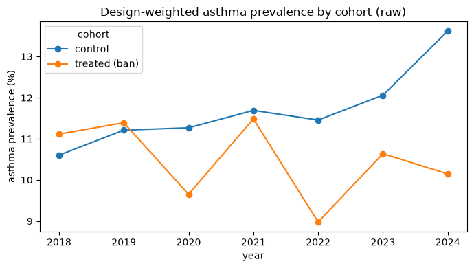

```python
print("First-treat-year (g) across states (0 = never-treated):")
print(micro.drop_duplicates("state")["g"].value_counts().sort_index())

fig, ax = plt.subplots(figsize=(7, 4))
labelled = micro.assign(
    cohort=np.where(micro["g"] > 0, "treated (ban)", "control"))
for lab, sub in labelled.groupby("cohort"):
    series = sub.groupby("year").apply(
        lambda d: np.average(d["asthnow"], weights=d["design_weight"]) * 100)
    series.plot(ax=ax, marker="o", label=lab)
ax.set(ylabel="asthma prevalence (%)", xlabel="year",
       title="Design-weighted asthma prevalence by cohort (raw)")
ax.legend(title="cohort")
plt.tight_layout()
plt.show()
```

## Step 2 — Make the survey representative (the descriptive estimand)

BRFSS design weights correct for the sampling *design*, not for **non-response**. Because younger adults increasingly drop out, the realized sample ages year over year, and — since older adults have more asthma — the design-weighted national prevalence drifts *upward* even when the true prevalence is flat or falling.

The standard fix is **poststratification / raking**: reweight each survey wave so its demographic margins match the population (here, ACS). `balance` does this with `adjust(method="rake", ...)`. We rake each year separately — the correct practice for a repeated cross-section — and compare the result against the true population prevalence.

```
      true_population  survey_design_weighted  survey_poststratified
2018            10.51                   10.81                  10.78
2019            10.55                   11.28                  10.77
2020             9.95                   10.61                   9.74
2021            10.02                   11.61                  10.32
2022             9.36                   10.47                   9.26
2023             9.41                   11.49                   9.76
2024             9.33                   12.23                  10.03
```

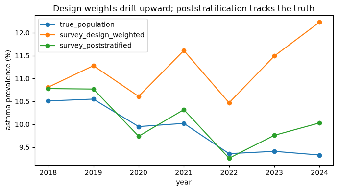

```python
def poststratify_by_wave(micro, acs):
    """Rake each annual wave to the ACS demographic margins. Returns the
    per-respondent weights and a dict {year: adjusted Sample} (one balance
    Sample per wave), used for the per-wave diagnostics in Step 6."""
    target = Sample.from_frame(acs, id_column="id")
    w = pd.Series(index=micro.index, dtype=float)
    adjs = {}
    for yr, idx in micro.groupby("year").groups.items():
        wave = micro.loc[idx]
        adj = (
            Sample.from_frame(wave, id_column="id", weight_column="design_weight",
                              outcome_columns=["asthnow"])
            .set_target(target)
            .adjust(method="rake", variables=RAKE_VARS)
        )
        # balance casts the id column to str in from_frame(); match on the str id.
        # The assert turns any future id-alignment change into a loud failure
        # instead of silent NaN weights.
        wt = (adj.df.set_index("id")[adj.weight_column]
              .reindex(wave["id"].astype(str).values).to_numpy())
        assert not np.isnan(wt).any(), "weight lookup produced NaNs (id alignment changed?)"
        w.loc[idx] = wt
        adjs[yr] = adj
    return w, adjs


w_py, adjs = poststratify_by_wave(micro, acs)
micro["w"] = w_py.values
# Latest wave (2024) is the most non-response-distorted here (drift grows over time).
adj_last = adjs[max(YEARS)]

trend = pd.DataFrame({
    "true_population": true_prev,
    "survey_design_weighted": micro.groupby("year").apply(
        lambda d: np.average(d["asthnow"], weights=d["design_weight"]) * 100),
    "survey_poststratified": micro.groupby("year").apply(
        lambda d: np.average(d["asthnow"], weights=d["w"]) * 100),
}).round(2)
print(trend)

ax = trend.plot(marker="o", figsize=(7, 4))
ax.set(ylabel="asthma prevalence (%)", xlabel="year",
       title="Design weights drift upward; poststratification tracks the truth")
plt.tight_layout()
plt.show()
```

The design-weighted series climbs while the true population prevalence is flat-to-declining (the bans are working) — the naive survey gets even the *direction* wrong. Poststratification recovers the truth.

`balance` also reports the diagnostics survey methodologists expect: covariate balance before/after (ASMD), the design effect, and the effective sample size. The Love plot is the canonical before/after balance visual.

```python
print(adj_last.summary())
adj_last.covars().love_plot()
```

```
Adjustment details:
    method: rake
Covariate diagnostics:
    Covar ASMD reduction: 90.9%
    Covar ASMD (21 variables): 0.049 -> 0.004
    Covar mean KLD reduction: 0.3%
    Covar mean KLD (13 variables): 11.046 -> 11.010
Weight diagnostics:
    design effect (Deff): 1.541
    effective sample size proportion (ESSP): 0.649
    effective sample size (ESS): 4762.3
Outcome weighted means:
            asthnow
source
self          0.100
unadjusted    0.122
```

## Step 3 — Survey-weighted Callaway–Sant'Anna via the adapter

Modern staggered-DiD estimators operate on a unit × period **panel**, not raw microdata. `balance.interop.diff_diff` bridges the two:

- `bd.to_panel_for_did(sample, ...)` builds the respondent-level `SurveyDesign` from the active balance weight, drops balance's book-keeping columns, and calls `diff_diff.aggregate_survey` to collapse respondents into a state-year panel of weighted prevalence (with design-based cell variances) — returning a `(panel_df, second_stage_design)` pair.
- `fit_did(...)` then builds the second-stage `SurveyDesign` and fits the chosen estimator, routing keyword arguments to `__init__`/`fit` for you.

We use [Callaway & Sant'Anna (2021)](https://arxiv.org/abs/1803.09015) with `estimation_method="reg"` (an outcome-regression DiD): `balance` has already handled covariate balance via poststratification, so the estimator only does the identification. We cluster by state and use a universal base period. We wrap the call so we can reuse it for the robustness check in Step 5.

```
Panel shape: (350, 13)
=====================================================================================
            Callaway-Sant'Anna Staggered Difference-in-Differences Results
=====================================================================================

Total observations:                   350
Treated units:                         20
Never-treated units:                   30
Treatment cohorts:                      2
Time periods:                           7
Control group:                 not_yet_treated
Base period:                    universal


-------------------------------------------------------------------------------------
                                    Survey Design
-------------------------------------------------------------------------------------
Weight type:                      pweight
PSU/Cluster:                           50
Effective sample size:               47.9
Kish DEFF (weights):                 1.04
Survey d.f.:                           49
-------------------------------------------------------------------------------------
-------------------------------------------------------------------------------------
                   Overall Average Treatment Effect on the Treated
-------------------------------------------------------------------------------------
Parameter           Estimate    Std. Err.     t-stat      P>|t|   Sig.
-------------------------------------------------------------------------------------
ATT                  -0.0300       0.0074     -4.079     0.0002    ***
-------------------------------------------------------------------------------------

95% Confidence Interval: [-0.0448, -0.0152]
CV (SE/abs(ATT)):             0.2451

-------------------------------------------------------------------------------------
                            Event Study (Dynamic) Effects
-------------------------------------------------------------------------------------
Rel. Period         Estimate    Std. Err.     t-stat      P>|t|   Sig.
-------------------------------------------------------------------------------------
-4.0                 -0.0136       0.0140     -0.972     0.3360
-3.0                 -0.0167       0.0132     -1.260     0.2137
-2.0                 -0.0025       0.0090     -0.284     0.7778
-1.0                  0.0000          nan        nan        nan
0.0                  -0.0377       0.0089     -4.230     0.0001    ***
1.0                  -0.0242       0.0082     -2.932     0.0051     **
2.0                  -0.0407       0.0082     -4.940     0.0000    ***
3.0                  -0.0107       0.0132     -0.812     0.4208
4.0                  -0.0252       0.0104     -2.428     0.0189      *
-------------------------------------------------------------------------------------

-------------------------------------------------------------------------------------
                             Effects by Treatment Cohort
-------------------------------------------------------------------------------------
Cohort              Estimate    Std. Err.     t-stat      P>|t|   Sig.
-------------------------------------------------------------------------------------
2020.0               -0.0257       0.0090     -2.862     0.0062     **
2022.0               -0.0376       0.0109     -3.441     0.0012     **
-------------------------------------------------------------------------------------

Signif. codes: '***' 0.001, '**' 0.01, '*' 0.05, '.' 0.1
=====================================================================================
```

[figure not shown]

```python
def run_did(weight_col):
    """Aggregate a weighted respondent sample to a state-year panel and fit
    Callaway-Sant'Anna, all through the balance<->diff-diff adapter."""
    sample = Sample.from_frame(micro, id_column="id", weight_column=weight_col,
                               outcome_columns=["asthnow"])
    panel_df, second_stage = bd.to_panel_for_did(
        sample, by=["state", "year"], outcomes="asthnow",
        second_stage_weights="pweight")
    # carry the cohort (g) onto the panel (one row per state-year)
    gmap = micro.drop_duplicates("state")[["state", "g"]]
    panel_df["state"] = panel_df["state"].astype(int)
    panel_df = panel_df.merge(gmap, on="state", how="left")
    panel_df["g"] = panel_df["g"].fillna(0).astype(int)
    panel_df["id"] = np.arange(len(panel_df))
    panel_sample = Sample.from_frame(
        panel_df, weight_column=second_stage.weights,
        outcome_columns=["asthnow_mean"])
    res = fit_did(
        panel_sample, estimator="CallawaySantAnna", outcome="asthnow_mean",
        time="year", unit="state", treatment_first="g",
        estimation_method="reg", control_group="not_yet_treated",
        base_period="universal", cluster="state", aggregate="all")
    return res, panel_df


res, panel_df = run_did("w")
print("Panel shape:", panel_df.shape)
print(res.summary())

ax = dd.plot_event_study(res)
ax.set_title("Callaway-Sant'Anna event study (survey-weighted)")
plt.tight_layout()
plt.show()
```

The event study shows flat, non-significant pre-treatment coefficients (parallel trends hold) and a clear post-treatment drop — an overall ATT of about −3 percentage points that recovers the planted effect.

## Step 4 — HonestDiD sensitivity to parallel-trends violations

Parallel trends is an assumption, not a fact. The [Rambachan & Roth (2023)](https://www.tandfonline.com/doi/full/10.1093/restud/rdad018) HonestDiD framework asks: how large could post-treatment violations be — relative to the largest pre-treatment violation (the relative-magnitude parameter `M`) — before the effect could be zero? `diff_diff.compute_honest_did` returns robust confidence intervals that widen with `M`. We sweep a few values to find the **breakdown** point rather than reporting a single pass/fail.

```python
print("HonestDiD (Rambachan & Roth 2023) relative-magnitude sensitivity:")
for m in (0.25, 0.5, 1.0, 1.5):
    h = compute_honest_did(res, method="relative_magnitude", M=m)
    excludes_zero = not (h.ci_lb <= 0 <= h.ci_ub)
    flag = "  <- still excludes 0" if excludes_zero else ""
    print(f"  M={m:>4}:  robust 95% CI = "
          f"[{h.ci_lb * 100:+.2f}, {h.ci_ub * 100:+.2f}] pp{flag}")
```

```
HonestDiD (Rambachan & Roth 2023) relative-magnitude sensitivity:
  M=0.25:  robust 95% CI = [-5.31, -0.23] pp  <- still excludes 0
  M= 0.5:  robust 95% CI = [-6.37, +0.83] pp
  M= 1.0:  robust 95% CI = [-8.49, +2.95] pp
  M= 1.5:  robust 95% CI = [-10.60, +5.07] pp
```

With only ~50 clusters the effect is robust to modest pre-trend violations but not unlimited ones — exactly the kind of honest caveat HonestDiD is designed to surface.

## Step 5 — Robustness: does the reweighting change the ATT?

A natural question is how much the survey weighting moves the *causal* estimate. We re-run the identical pipeline on the **raw design weights** (no poststratification) and compare. Because a DiD differences out time-invariant composition, the common non-response drift largely cancels: the ATT is **robust**. The weighting's payoff is elsewhere — an unbiased descriptive trend (Step 2) and design-consistent standard errors — and the agreement here is reassurance, not redundancy.

```python
res_design, _ = run_did("design_weight")

print("Planted true ATT      : %+.2f pp" % true_att_pp)
print("Design-weighted ATT   : %+.2f pp" % (res_design.overall_att * 100))
print("Poststratified ATT    : %+.2f pp" % (res.overall_att * 100))
```

```
Planted true ATT      : -3.15 pp
Design-weighted ATT   : -3.44 pp
Poststratified ATT    : -3.00 pp
```

## Step 6 — Combined and per-wave diagnostics

`bd.as_balance_diagnostic(sample, did_results)` joins balance's pre-fit diagnostics (ASMD, Kish ESS, design effect) for a given adjusted `Sample` with diff-diff's post-fit survey-design diagnostics for the fitted DiD, into one flat dict.

Because we poststratify **each wave separately**, there is no single pipeline-wide adjusted `Sample` — the balance-side metrics are inherently per wave. So we report two things: a **per-wave** covariate-balance table across all seven waves, and the combined `as_balance_diagnostic` dict for the **most non-response-distorted wave (2024)** paired with the full-panel DiD result. Read the combined dict carefully: its `diff_diff_*`/`att` entries describe the whole 2018–2024 panel, while its `balance_*` entries describe only the 2024 wave.

```python
# Per-wave covariate-balance diagnostics (balance side), via the adapter helper.
BAL_KEYS = ["balance_asmd_mean_post", "balance_asmd_max_post",
            "balance_kish_ess", "balance_design_effect"]
per_wave = pd.DataFrame(
    {yr: {k: as_balance_diagnostic(a, res)[k] for k in BAL_KEYS}
     for yr, a in adjs.items()}
).T
per_wave.index.name = "year"
print("Per-wave balance diagnostics (all waves):")
print(per_wave.round(3))

# Combined dict: balance side = 2024 wave (most distorted); diff-diff side = full panel.
print("\nCombined diagnostic (balance=2024 wave, diff-diff=full 2018-2024 panel):")
diag = as_balance_diagnostic(adj_last, res)
pd.DataFrame([diag]).T.rename(columns={0: "value"})
```

```
Per-wave balance diagnostics (all waves):
      balance_asmd_mean_post  balance_asmd_max_post  balance_kish_ess  \
year
2018                   0.000                  0.004          7589.334
2019                   0.001                  0.009          7568.501
2020                   0.001                  0.010          7125.488
2021                   0.002                  0.025          6676.885
2022                   0.003                  0.035          6262.412
2023                   0.004                  0.037          5451.842
2024                   0.004                  0.050          4762.253

      balance_design_effect
year
2018                  1.063
2019                  1.068
2020                  1.098
2021                  1.157
2022                  1.217
2023                  1.358
2024                  1.541

Combined diagnostic (balance=2024 wave, diff-diff=full 2018-2024 panel):
```

|  | value |
| --- | --- |
| att | -0.030014 |
| se | 0.007357 |
| conf_int | (-0.04479875661771691, -0.015228739590515752) |
| n_obs | 350 |
| diff_diff_design_effect | 1.044851 |
| diff_diff_effective_n | 47.853733 |
| diff_diff_sum_weights | 7724.571429 |
| balance_kish_ess | 4762.253361 |
| balance_design_effect | 1.541497 |
| balance_asmd_mean_post | 0.004465 |
| balance_asmd_max_post | 0.049575 |

## Discussion

What this notebook demonstrated:

- A respondent-level BRFSS-shaped survey with realistic differential non-response is made population-representative with `balance` poststratification — fixing a descriptive prevalence trend that the raw design weights get *backwards*.
- The reweighted sample is handed to `diff-diff` through a single `bd.to_panel_for_did` + `fit_did` pair: respondents are aggregated to a state-year panel and a survey-weighted Callaway–Sant'Anna ATT is fit with design-based standard errors.
- Parallel-trends sensitivity (HonestDiD) and a combined diagnostic are each one line.
- The causal ATT is **robust** to the reweighting (composition differences out in a DiD), while the survey weights remain essential for the descriptive estimand and for valid inference.

What to try next:

1. **Real BRFSS data**: replace the data-generating cell with `pyreadstat.read_xport(...)` per year and concatenate; the rest is unchanged.
2. **Other estimators**: swap `estimator="CallawaySantAnna"` for `"SunAbraham"`, `"ImputationDiD"`, or `"WooldridgeDiD"` — the adapter resolves any estimator exported by `diff_diff`.
3. **Other reweighting**: try `method="ipw"` or `method="cbps"` in `poststratify_by_wave` — the adapter is weighting-method agnostic.
4. **Continuous treatment**: `dd.ContinuousDiD` works for dose-of-policy designs.
5. **Cross-language replication**: compare against R's `survey::svydesign` + `did::att_gt` for a JSS / Epidemiology-Methods note.

## References

### Methodology

- [Callaway, B., & Sant'Anna, P. H. C. (2021). *Difference-in-differences with multiple time periods.* Journal of Econometrics, 225(2), 200-230.](https://arxiv.org/abs/1803.09015) — the ATT(g, t) estimator behind `CallawaySantAnna`.
- [Sant'Anna, P. H. C., & Zhao, J. (2020). *Doubly robust difference-in-differences estimators.* Journal of Econometrics, 219(1), 101-122.](https://arxiv.org/abs/1812.01723) — the doubly-robust DiD operationalised by `estimation_method="dr"`.
- [Rambachan, A., & Roth, J. (2023). *A more credible approach to parallel trends.* Review of Economic Studies, 90(5), 2555-2591.](https://www.tandfonline.com/doi/full/10.1093/restud/rdad018) — the HonestDiD sensitivity framework used in Step 4.
- [Sarig, T., Galili, T., & Eilat, R. (2023). *balance - a Python package for balancing biased data samples.* arXiv 2307.06024.](https://arxiv.org/abs/2307.06024) — the balance package paper.
- [Ghandour, K., & Reece, A. (2025). *diff-diff: Modern Difference-in-Differences in Python.* Zenodo, DOI 10.5281/zenodo.19646175.](https://doi.org/10.5281/zenodo.19646175) — the diff-diff package citation.

### Data

- [CDC Behavioral Risk Factor Surveillance System (BRFSS).](https://www.cdc.gov/brfss/annual_data/annual_2024.html) — the public-use file this notebook's synthetic frame mirrors.
- [Census ACS 1-year PUMS.](https://www.census.gov/programs-surveys/acs/microdata.html) — the demographic-margin target frame.

### Related tutorials

- [`balance_quickstart`](https://import-balance.org/docs/tutorials/quickstart/)
- [`balance_quickstart_cbps`](https://import-balance.org/docs/tutorials/quickstart_cbps/)